# SEM practical

Oscar Rodriguez de Rivera

University of Exeter

Structural equation modeling (SEM) is a model selection approach to path analysis that either includes latent variables or statistically compares different path models with the goal of comparing different causal hypotheses and examining indirect effects. I think these are best understood through visualization, in fact the heuristic visualization provided by a path diagram is a strength of the approach.

```r
library(lavaan)
```

```r
library(lavaanPlot)
library(piecewiseSEM)
library(tidyverse)
set.seed(2002)
```

Here we will simulate data of caterpillar richness measured over 60 years. First I simulate that temperature is increasing. Then I simulate that caterpillar richness is declining as a function of both temperature and year. Then I add a precip variable with no trends and no effect on caterpillars.

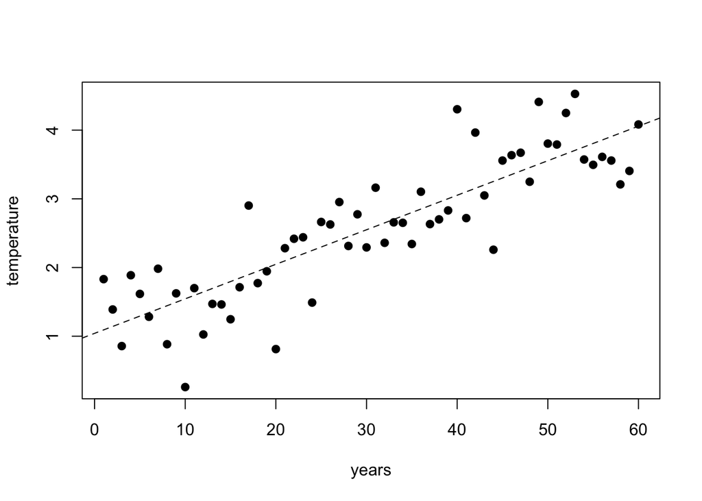

```r
## years
years <- c(1:60)

#precip variable
precip <- rnorm(60, mean=100, sd=10)

## simulate the increasing temperature anomolies
temperature <-  .05 + .05*years + rnorm(length(years),1,.5)
plot(temperature ~ years,pch=19); abline(lm(temperature ~ years),lty=2)
```

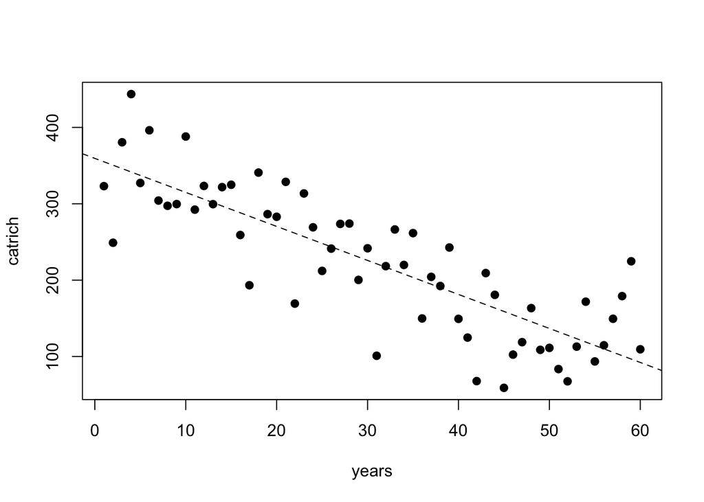

```r
## simulate the caterpillar richness as a function of years and temps
catrich <-  350 -2*years -50*temperature + rnorm(length(years),50,50)
plot(catrich ~ years,pch=19); abline(lm(catrich ~ years),lty=2)
```

```r
semdata <- cbind(catrich, years, temperature, precip)
```

```r
cov(semdata)
```

```
##                 catrich       years temperature      precip
## catrich      8825.22098 -1358.42825 -82.1936621  90.2473145
## years       -1358.42825   305.00000  15.3312769 -23.4048821
## temperature   -82.19366    15.33128   1.0431215   0.2863871
## precip         90.24731   -23.40488   0.2863871  97.8564803
```

```r
model1 <- 'precip ~ years
    catrich ~ years
    catrich ~ temperature
    temperature ~ years'

fit1 <- sem(model1, data = semdata)
summary(fit1,rsq = T, fit.measures = TRUE, standardized = TRUE)
```

```
## lavaan 0.6.17 ended normally after 22 iterations
##
##   Estimator                                         ML
##   Optimization method                           NLMINB
##   Number of model parameters                         8
##
##   Number of observations                            60
##
## Model Test User Model:
##
##   Test statistic                                 5.118
##   Degrees of freedom                                 1
##   P-value (Chi-square)                           0.024
##
## Model Test Baseline Model:
##
##   Test statistic                               175.155
##   Degrees of freedom                                 6
##   P-value                                        0.000
##
## User Model versus Baseline Model:
##
##   Comparative Fit Index (CFI)                    0.976
##   Tucker-Lewis Index (TLI)                       0.854
##
## Loglikelihood and Information Criteria:
##
##   Loglikelihood user model (H0)               -580.210
##   Loglikelihood unrestricted model (H1)       -577.651
##
##   Akaike (AIC)                                1176.420
##   Bayesian (BIC)                              1193.175
##   Sample-size adjusted Bayesian (SABIC)       1168.013
##
## Root Mean Square Error of Approximation:
##
##   RMSEA                                          0.262
##   90 Percent confidence interval - lower         0.077
##   90 Percent confidence interval - upper         0.504
##   P-value H_0: RMSEA <= 0.050                    0.034
```

[output cut: 23 more lines]

```
##                    Estimate  Std.Err  z-value  P(>|z|)   Std.lv  Std.all
##  .precip ~~
##    .catrich          64.990   57.207    1.136    0.256   64.990    0.148
##
## Variances:
##                    Estimate  Std.Err  z-value  P(>|z|)   Std.lv  Std.all
##    .precip           94.460   17.246    5.477    0.000   94.460    0.982
##    .catrich        2034.061  371.367    5.477    0.000 2034.061    0.231
##    .temperature       0.268    0.049    5.477    0.000    0.268    0.261
##
## R-Square:
##                    Estimate
##     precip            0.018
##     catrich           0.769
##     temperature       0.739
```

#### Model Fit Estimates

The general goal of SEM is to identify a set of maximally likely population parameters given a) the variances and covariances of the observed data and b) several user-specified paths thought to give rise to said variances and covariances. Thus, model fit is based on the comparison of the observed variance-covariance matrix and model-implied covariance matrix. If the model is an accurate representation of the patterns among the data, the variance-covariance matrix using the estimated parameters should match the variance-covariance of the sample or observed matrix.

A. Estimator Methods

• Indicates the Maximum Liklihood (ML) was used to estimate parameters. still fuzzy on ML? click here.

• the optimizer that was used to find the best fitting parameter values for this estimator (here: NLMINB) • the number of model parameters (here: 8). 4 estimates for regression parameters + 1 estimate for convariance + 3 estimates for variances = 8 parameters

B. Model Test User Model

•Test statistic for the model that was specified by the user/ the fitted model. Here, the test statistic calculated is a Chi-squared test statistic and represents the observed Chi-square value for the fitted model. •Degrees of freedom for the fitted (n=1 because df fro the model= (number of covariances) - (number of parameters) •p-value for the fitted model. Model significance was tested from Chi-square null hypothesis test. The null hypothesis is: the fitted model-implied covariance matrix and the observed sample covariance matrix are equal. If our specified model was “good” we would accept that null hypothesis. If the specified model is poor fit for the the data, then we would reject the null. Simply put, a high p-value is desired because its structure properly represents relationships in the data.

C. Model Test Baseline Model

The baseline model represents a null model whereby your observed variables are constrained to covary with no other variables- covariances are fixed to 0 such that only variances are estimated in the covariance matrix. It represents a poor fitting mode. This is tested against your fitted model.

• minimum function test statistic is the test statistic for the null model (chi-square value)

• degrees of freedom for the null model • p-value for the null model compared to the fitted model.

D-G) More model fit statistics

A bunch of other model fit statistics. Beyond the scope of this lesson. In the spirit of somewhat arbitrary cut-offs: RMSEA less than 0.05, CFI/TLI above 0.90 to 0.95, and SRMR less than 0.08 are accepted as indicators of “good fit” refer to Hu and Bentler (1999).

#### Parameter Estimates

H. Regression Coefficients

Values in this section get interpreted just like any other linear model. These are the path coefficients that are presented on the path diagrams.

• Std.err: Contains the standard error for each estimated parameter

• Z-value: contains the Wald statistic (which is simply obtained by dividing the parameter value by its standard error), and the last column (P(>|z|)) contains the p-value for testing the null hypothesis that the parameter equals zero in the population

I, J) Variance Covariance Outputs

In these sections it is important to note that a (.) before the variable term (e.g., .precip) indicates that it is a residual term. Also, variances and covariance can be displayed on the path diagram abd there are specific ways to illustrate those relationships, however, this information is often omitted from published path diagrams for simplification. Published path diagrams, in ecology, typically only include edges representing the regression coefficients.

I. Covariances

J. Variances

```r
#summary(fit1, rsq = T, fit.measures = TRUE)

lavaanPlot(name = "MODEL1", fit1, labels = semdata, coefs = TRUE)
```

[interactive chart not shown]

Here we see the relationships between all of the variables. In SEMs, path coefficients are the regressions coefficients standardized by the standard deviation of the predictor variable in the causal pathway.

Before I move on to interpretation, is there something going on here that might impact interpretation of the model?

Let’s scale our variables.

```r
semdata_scaled <- apply(semdata, MARGIN = 2, scale)

model2 <- 'precip ~ years
    catrich ~ years
    catrich ~ temperature
    temperature ~ years'

fit2 <- sem(model2, data = semdata_scaled)
#summary(fit2, rsq = T, fit.measures = TRUE)

lavaanPlot(name = "MODEL2", fit2, labels = semdata_scaled, coefs = TRUE)
```

[interactive chart not shown]

SEM is especially powerful when we use them to test different hypotheses and perform model comparison. This next model does not model a trend in caterpillars over time. We can then perform model comparison using AIC or some other metric.

```r
semdata_scaled <- apply(semdata, MARGIN = 2, scale)

model3 <- 'precip ~ years
    catrich ~ temperature
    temperature ~ years'

fit3 <- sem(model3, data = semdata_scaled)
#summary(fit3, rsq = T, fit.measures = TRUE)

lavaanPlot(name = "MODEL3", fit3, labels = semdata_scaled, coefs = TRUE)
```

[interactive chart not shown]

```r
AIC(fit1, fit2, fit3)
```

```
##      df       AIC
## fit1  8 1176.4203
## fit2  8  353.7550
## fit3  7  357.7849
```

Our second model appears to be the best, so let’s take a closer look. We can see that years has a positive effects on temperature, which is to say that temperature is increasing over time. We can also see that temperature has a direct negative effect on caterpillar richness. There is a also slight negative trend richness over time after accounting for temperature change and a slight negative trend in precip. The precip result should be interpreted with caution, as we did not simulate a relationship between precip and year. In fact if you look at the model output, the is no reason to suspect this is not due to random noise (high p-value).

Now for the indirect effect. We only have on in this model, it is the impact of year on caterpillar richness that is mediated by temperature change. We can calculate the total effect by multiplying the path coefficients. So the total impact of year on caterpillars is (-0.32 + (0.86 * -0.6)), which is -0.836.

Another note in SEMs is the interpretation of the of the chi squared p value. Here the null hypothesis is that our data match the model that we provide, so a higher p-value indicates better model fit. However, if you dive into the regression coefficients, these p-values should be interpreted like any other from a linear model.